# PLSC 500: Section 5

October 3, 2016

## Plotting Functions

## Create a Distribution

```r
library(dplyr)
library(ggplot2)
set.seed(500)
```

Often, we have a distribution of data that we would like to visualize.

```r
data <- data_frame(
                   x = seq(-6, 6, length.out = 10000),
                   y = 2 * x + x^2 + 20 * rnorm(x)
                  )
```

Here, we have \(Y\) as a quadratic function of \(X\), with normally distributed noise indicated by `rnorm(x)`.

## Plotting the Distribution

Let's go ahead and plot that:

```r
plot1 <-
  ggplot(data, aes(x = x, y = y)) +
    geom_point(alpha = 0.25) +
    theme_bw()
```

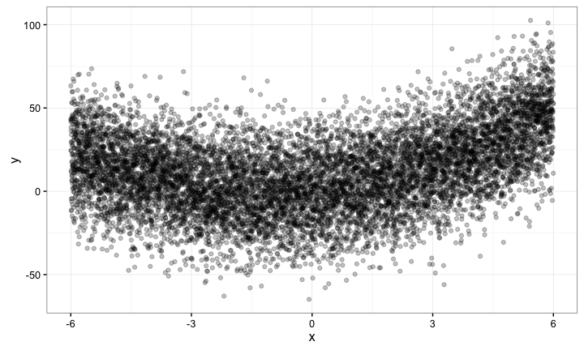

```r
plot1
```

## Our Goal

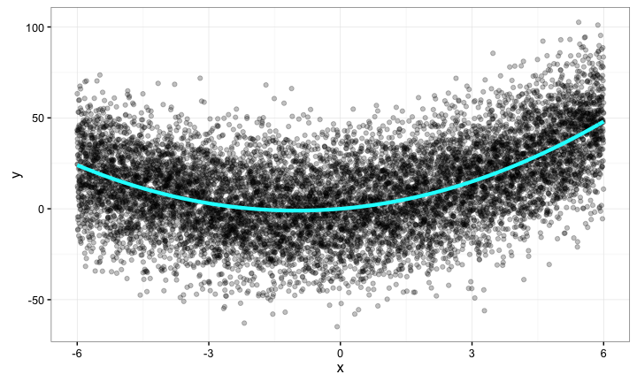

## Defining Functions

Since we know the data generating process, how could we plot the CEF onto this graph?

First, we define the function.

```r
CEF <- function(x) {
  return(2 * x + x^2)
}
```

## stat_function()

```r
plot1 +
  stat_function(fun = CEF, col = "cyan", size = 1.5)
```

What does `stat_function()` do?

It takes a function (`fun`) as an input, and calculates the value of `fun` for every value of *X*.

It then plots that as a line (by default) on top of the existing graph.

## Modularity in **ggplot2**

**ggplot2** works a lot like **R**: the plots *and their components* are objects

```r
cef_plot <- stat_function(fun = CEF,
                          col = "cyan",
                          size = 1.5)
```

We can now use `cef_plot` over and over again:

```r
plot1 + cef_plot
```

## Anonymous Functions

We can also invoke *anonymous functions* with `stat.function()`:

```r
plot1 + stat_function(fun = function(x) 2 * x + x^2,
                      col = "cyan",
                      size = 1.5)
```

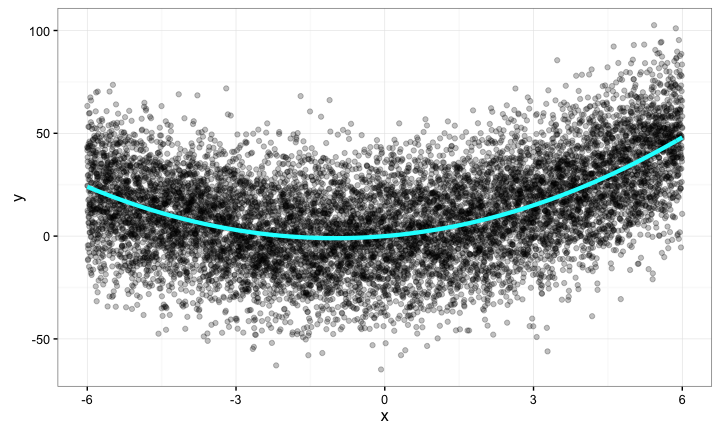

```r
plot1 + cef_plot
```

## Best Linear Predictor

What if we want to plot the best *line*?

- What do we mean by "best"?
  - The line that minimizes *mean squared error*
- What is mean squared error?
  - For an estimate \(c\):
  - \(MSE = \text{E}\big[(X - c)^2\big]\)
- How do we calculate the best linear predictor to the CEF?

## Best Linear Predictor Equation

\[ Y = \alpha + \beta X \]

What is \(\alpha\)?

\[ \alpha = \text{E}[Y] - \frac{\text{Cov}[X,Y]}{\text{V}[X]}\,\text{E}[X] \]

What is \(\beta\)?

\[ \beta = \frac{\text{Cov}[X,Y]}{\text{V}[X]} \]

In other words:

\[ \alpha = \text{E}[Y] - \beta\,\text{E}[X] \]

## Calculate Intercept

Let's start by calculating the value of \(\alpha\):

```r
alpha <-
  mean(data$y) - (cov(data$x, data$y) / var(data$x)) * mean(data$x)

alpha
```

```
## [1] 11.97447
```

That looks pretty clunky with all of the `data$` terms. Let's simplify:

```r
alpha <- with(data,
              mean(y) - (cov(x, y) / var(x)) * mean(x)
              )
```

## Calculate Slope

Now repeat for \(\beta\):

```r
beta <- with(data,
             cov(x, y) / var(x)
             )

beta
```

```
## [1] 2.082254
```

## Best Linear Predictor Function

Now we need to write a function for our BLP so that **R** can use it.

```r
BLP <- function(x) {
  return(alpha + beta * x)
}
```

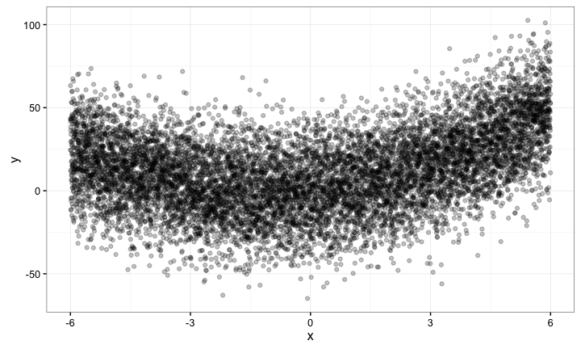

```r
plot1
```

## Plotting BLP

How do we add the BLP onto the plot?

```r
plot_blp <- plot1 +
              stat_function(fun = BLP,
                            col = "yellow", size = 1.5)
```

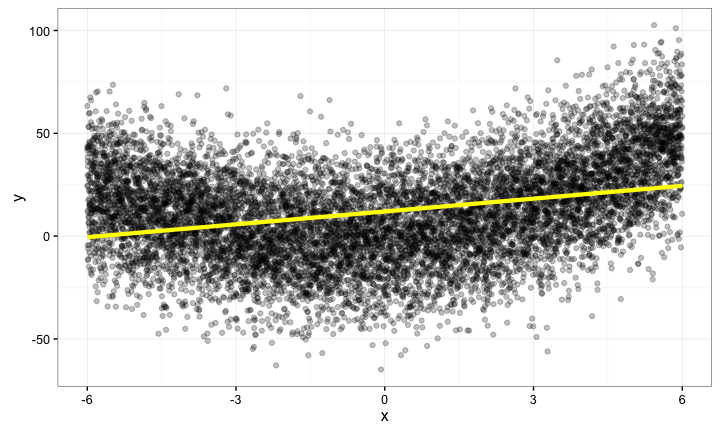

```r
plot_blp
```

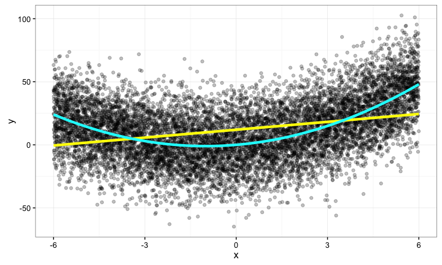

```r
plot_blp + cef_plot
```

## geom_smooth()

An easier way!

```r
plot_blp_easy <- plot_blp +
  geom_smooth(method = "lm", se = FALSE,
              col = "red", linetype = 2)
```

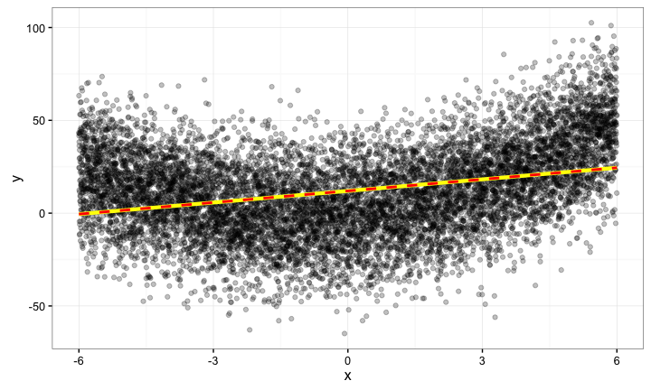

```r
plot_blp_easy
```

## Simulation!

First, we create potential values for \(\mu\) and \(\sigma\):

```r
x <- seq(-10, 10, length.out = 100)
mu <- seq(-5, 5, length.out = 100)
sigma  <- seq(1, 11, length.out = 100)
```

## Making Guesses

We first need a place to store our guesses and the results

```r
guesses <- matrix(NA,
                  nrow = length(mu),
                  ncol = length(sigma),
                  dimnames = list(
                    mu, sigma
                    )
                  )

rownames(guesses) <- mu
colnames(guesses) <- sigma
```

## Create a Loop

```r
for(i in 1:nrow(guesses)){
  for(j in 1:ncol(guesses)){
    guesses[i, j] <- max(dnorm(x, mean = mu[i], sd = sigma[j]))
    }
}
```

## Results

```r
arrayInd(which(guesses == max(guesses)), .dim = dim(guesses),
         .dimnames = dimnames(guesses),
         useNames = TRUE)
```

```
##                    row col
## -1.86868686868687   32   1
## -1.76767676767677   33   1
## -0.959595959595959  41   1
## 1.66666666666667    67   1
## 2.47474747474747    75   1
```

Notice that all of the results are in column 1

What is the standard deviation in column 1?

What can we take away from this? How do we maximize the height of the normal PDF?